# HW#1

**Problem 1** Malnourishment in elderly patients is associated with an increasing risk of adverse clinical events and mortality, and an increasing length of hospital stay. Furthermore, persistent malnourishment can lead to deficiencies in various nutritional markers, including vitamin B12 and B6, and folate. O'Leary and collegues (2011) conducted a cross-sectional study of 52 patients aged $\ge$ 60 years who were admitted to a sub-acute geriatric rehailitation unit in Australia. The aim of the study was to examine association between the vitamin B12, B6 and folate, homocystein and methylmalonic acid (MMA), dietary intake, nutritional status and length of stay.

Length of stay was positively correlated with age and MMA (Spearman correlation coefficient ($r_s$) 0.4 $P<0.01$ and 0.28 $P<0.05$, respectively) and negatively correlated with albumin, vitamin B6 and the Mini Nutritional Assessment (MNA) score ($r_s$ -0.35, -0.33 and -0.29, respectively, and $P<0.05$ for each). When the authors compared subjects whose length of stay was <21 days to subjects whose length of stay was $\ge$ 21 days, those with longer of stay were on average, marginally older ($P=0.054$), had lower vitamin B6 ($P=0.025$) and lower serum folate concentrations ($P=0.035$) and had more B vitamin deficiencies ($P=0.026$) than those with shorter lengths of stay (Table 1)

**Table 1** Characteristics of subjects

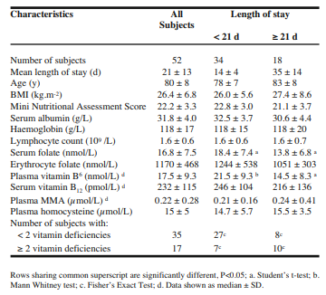

a) Interpret the reported correlations between length of stay and age, MMA and albumin, as well as the results of any significance tests which relate to these correlation coefficient. When would it be most appropriate to display the Spearman correlation coefficient rather than the Pearson correlation coefficient when assessing the association between two values? Is there any evidence to suggest that this was appropriate in this situation?

b) Comment on the way in which the authors have chosen to present the *P*-values for these correlation coefficients.

c) For most of the variables shown in Table 1, the authors chose to present mean values with SDs. For three variables (plasma vitamin B6, serum vitamin B12 and plasma MMA), however, the authors presented medians with standard deviations. Why do you think they presented medians instead of means for these variables? Comments on the appropriateness of presenting standard deviations for these three variables. Finally, comment on the appropriateness of presenting mean values for the other variables in Table 1, particularly length of stay. What further information would you like to see to help you answer this question?

d) The authors compared subjects who were hospitalised for $<$21 days with those hospitalised for $\ge$21 days. What test(s) would they have used to make comparisons of any numerical variables in Table 1? Give reasons for your answers

e) The authors used a Fisher's exact test to compare the proportion of subjects with $<$2 or $\ge$2 vitamin deficiencies between the two groups. Why do you believe that they did this? Using the numbers provided in Table 1, investigate whether Fisher's exact test was optimal in this situation. If it was not optimal, what alternative test cold have been performed?

**Reference** *O'Leary F et al. (2011). B vitamin status, dietary intake and length of stay in a sample of elderly rehabilitation patients. *J Nutr Health Aging*, **15**, 485-489*

**Problem 2** It has been reported that older individuals experiencing severe burns have a higher mortality rate than younger individuals with severe burns. To asseess whether any differences in mortality can explained by differences in demographic or clinical characteristics of older and younger individuals. Albornoz and colleagures (2011) described a case-control study of 66 patiensts aged 65 years or older (case: over-65 group) and 22 patiens younger than 65 years (control: under-65 years) who were admitted with severe burns to the intermediate and intensive care unit of the National Burn Adult Reference Centre in Santiago, Chile. The investigators collected information on the burn agent (eg. fire or scald), wether inhalation injuries were present, the burn surface area expressed as a percentage of the total body surface area (%TBSA), the deep burn surgace area, also expressed as a percentage (%DTBSA), the DTBSA:TBSA proportion and the primary outcomes of the study were the length of stay in the intensive care unit and mortality.

A summary of the characteristics of patients in the two groups is shown in Table 2. In unadjusted analyses, the mortality rate was significantly higher in the over-65 group (odds ratio 2.9, 95% confidence interval 1.6-5.2, $P<$0.001); after controlling for other potential confounders in a multivariable logistic regression analysis, those aged $\ge$65 years were over 12 times more likely to die from their burn than those in the younger age group (adjusted odds ratio 12.02, $P<$0.001). The adjusted odds ratio for %TBSA was 1.06 per unit increment ($P<$0.001), where as that for the DTBSA:TBSA proportion was 7.6 per unit increment ($P<$0.001). After adjustment using a multivariable logistic regression analysis, there were no significant associations between mortality and gender, the presence of inhalation injuries or any other comobidities (eg. epilepsy, obesity, smoking or cardiovascular disease).

**Table 2** Summary of main characteristics of the over-65 and under-65 groups.

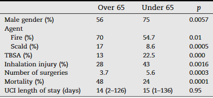

a) Explain why the study cannot be decribed as a case-control study. What would be a more appropriate description of the study design?

b) Comment on the distributions of the numerical variables summarised in Table 2. Do you agree with the authors' choice of summary measures for each variable? If not, what are your reasons for this and what summary measure would you choose to present instead?

c) Using the data provided in Table 2, demonstrate how the authors would have calculated the unadjusted odds ratio for mortality?

d) Why did the authors feel that it was important to perform a multivariable logistic regression in this situation? Interpret the adjusted odds ratio provided in the test and its $P$-value. Why is the adjusted odds ratio so much higher than the unadjusted odds ratio?

**Reference** *Albornz CR et al. (2011) Burns are more aggressive in the elderly: proportion of deep burn area/total burn area might have a role in mortality, Burns, **37**, 1058-1561.*